# Лабораторная работа №13

Статическая маршрутизация в Интернете. Планирование

Авдадаев Джамал Геланиевич

Российский университет дружбы народов, Москва, Россия

05 мая 2026

# Цели и задачи работы

## Цель лабораторной работы

Провести подготовительные мероприятия по организации взаимодействия через сеть провайдера посредством статической маршрутизации локальной сети с сетью основного здания, расположенного в 42-м квартале в Москве, и сетью филиала, расположенного в г. Сочи.

# Ход выполнения работы

## Дополнение схемы проекта

В проект были добавлены две новые подсети:

- подсеть основной территории организации в 42-м квартале Москвы
- подсеть филиала организации в г. Сочи

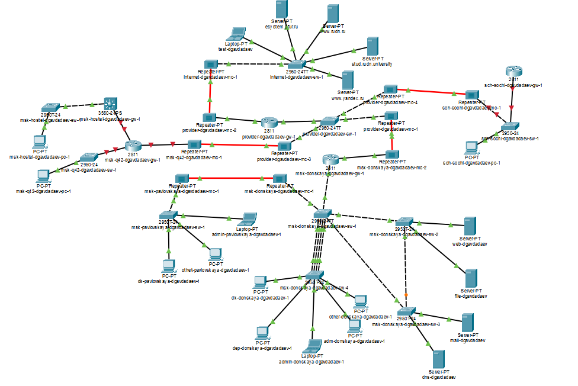

Общая схема проекта после добавления новых подсетей

## Территориальная схема связи

В физической рабочей области Cisco Packet Tracer была построена территориальная схема взаимодействия между площадками Москва и Сочи.

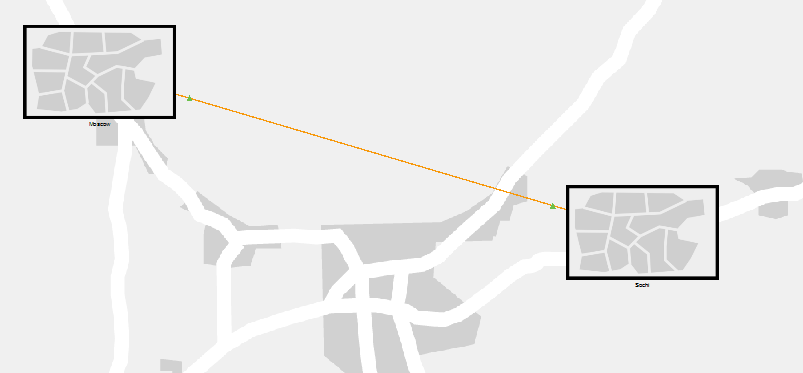

Территориальная схема связи между Москвой и Сочи

## Московский сегмент сети

В московский сегмент сети была добавлена новая площадка основной территории организации в 42-м квартале.

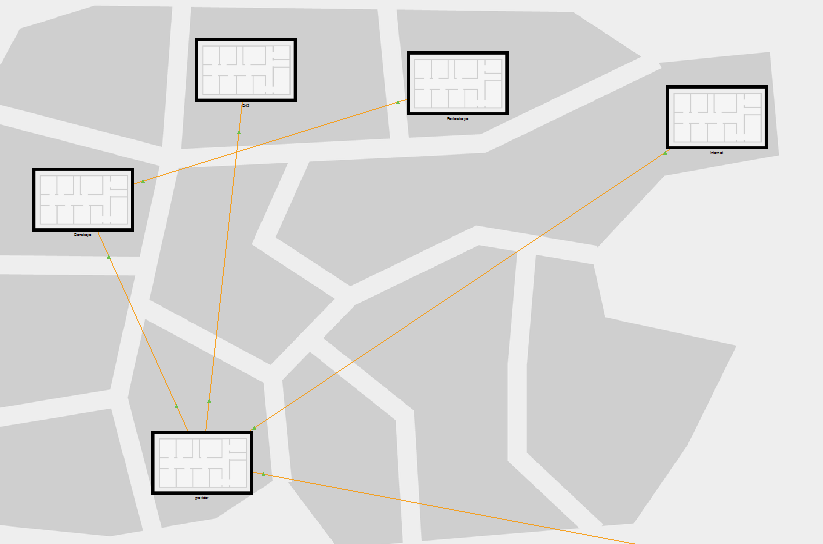

Физическая схема площадок московского сегмента сети

## Подсеть 42-го квартала в Москве

Для основной территории организации была создана отдельная подсеть, включающая маршрутизатор, коммутатор и пользовательские устройства.

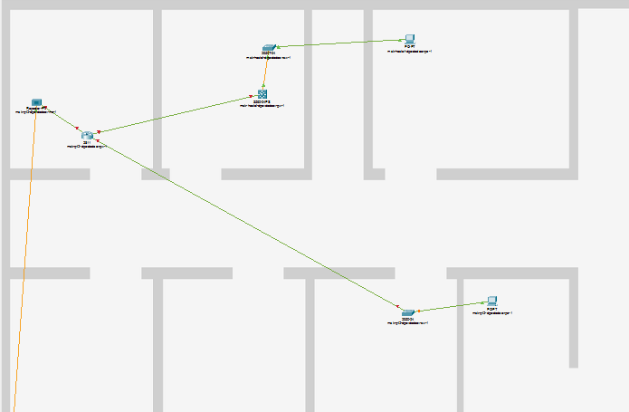

Подсеть основной территории организации 42-го квартала

## Подсеть филиала в г. Сочи

Для филиала в г. Сочи была сформирована отдельная локальная сеть, подключенная к общей корпоративной инфраструктуре.

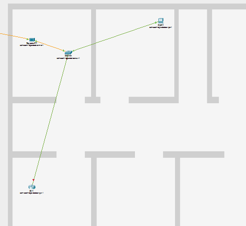

Подсеть филиала в г. Сочи

# Первоначальная настройка оборудования

## Состав первоначальной настройки

Для добавленных маршрутизаторов и коммутаторов была выполнена базовая конфигурация.

Основные этапы настройки:

- назначение имени устройства
- настройка консольного доступа
- настройка VTY-линий
- включение пароля привилегированного режима
- включение шифрования паролей
- создание пользователя администратора
- настройка доменного имени
- генерация RSA-ключей
- включение удалённого доступа по SSH
- сохранение конфигурации

## Настройка msk-q42-dgavadadev-gw-1

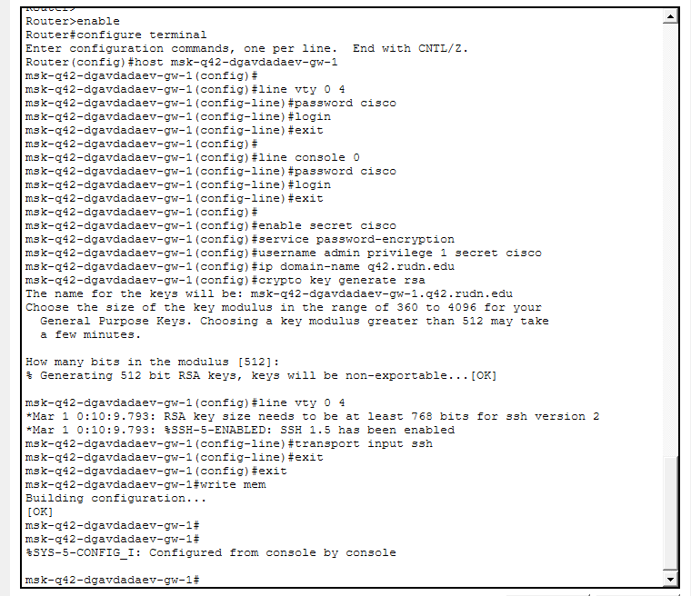

Первоначальная настройка маршрутизатора msk-q42-dgavadadev-gw-1

## Настройка msk-q42-dgavadadev-sw-1

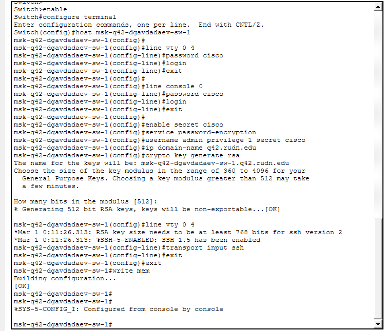

Первоначальная настройка коммутатора msk-q42-dgavadadev-sw-1

## Настройка msk-hostel-dgavadadev-gw-1

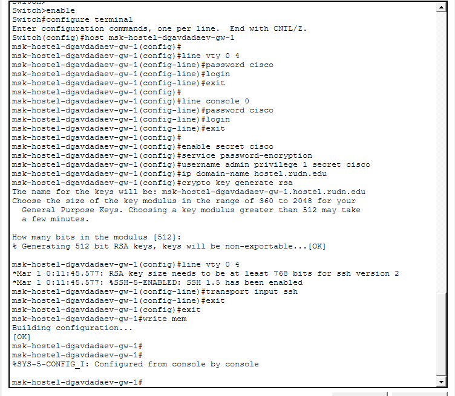

Первоначальная настройка маршрутизатора msk-hostel-dgavadadev-gw-1

## Настройка msk-hostel-dgavadadev-sw-1

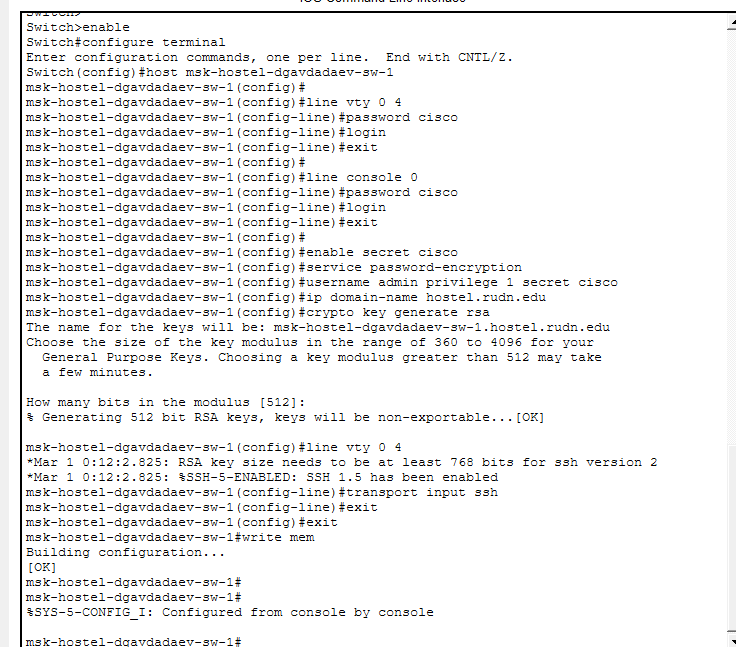

Первоначальная настройка коммутатора msk-hostel-dgavadadev-sw-1

## Настройка sch-sochi-dgavadadev-sw-1

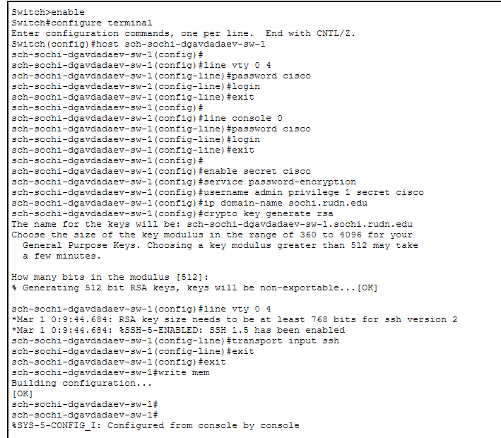

Первоначальная настройка коммутатора sch-sochi-dgavadadev-sw-1

## Настройка sch-sochi-dgavadadev-gw-1

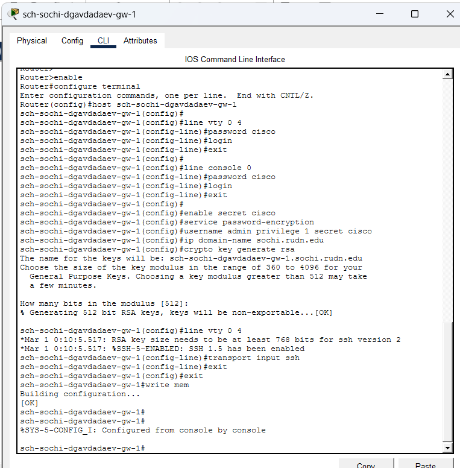

Первоначальная настройка маршрутизатора sch-sochi-dgavadadev-gw-1

# Схемы сети

## Схема сети уровня L1

На схеме L1 отражена физическая структура сети: оборудование, интерфейсы и каналы связи между устройствами.

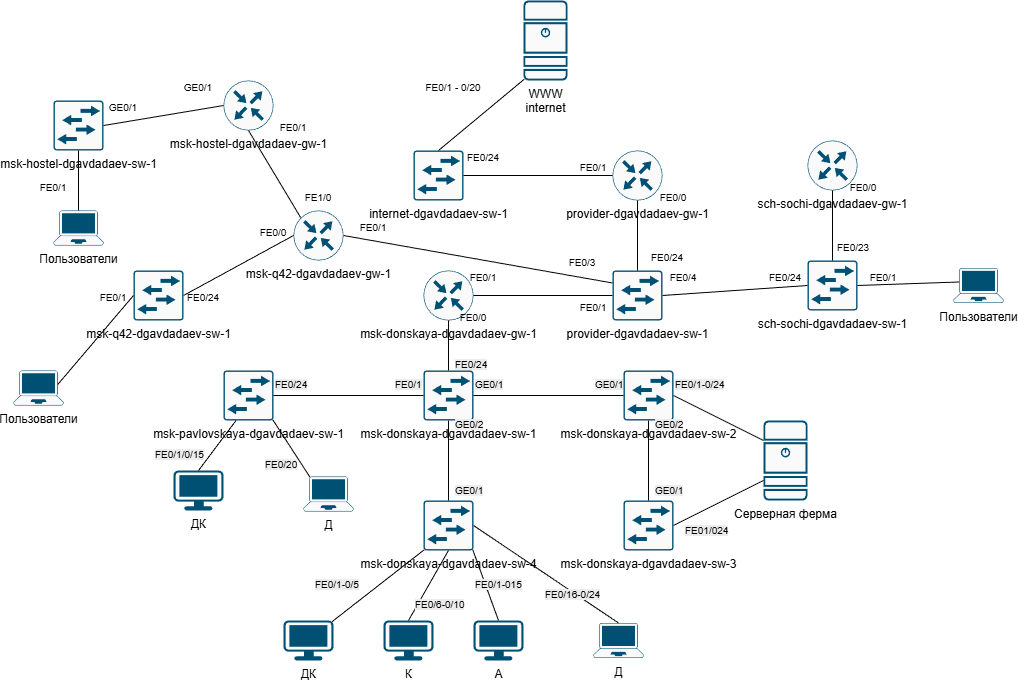

Схема сети уровня L1

## Схема сети уровня L2

На схеме L2 показана канальная структура сети, включая связи между коммутаторами, маршрутизаторами и конечными узлами.

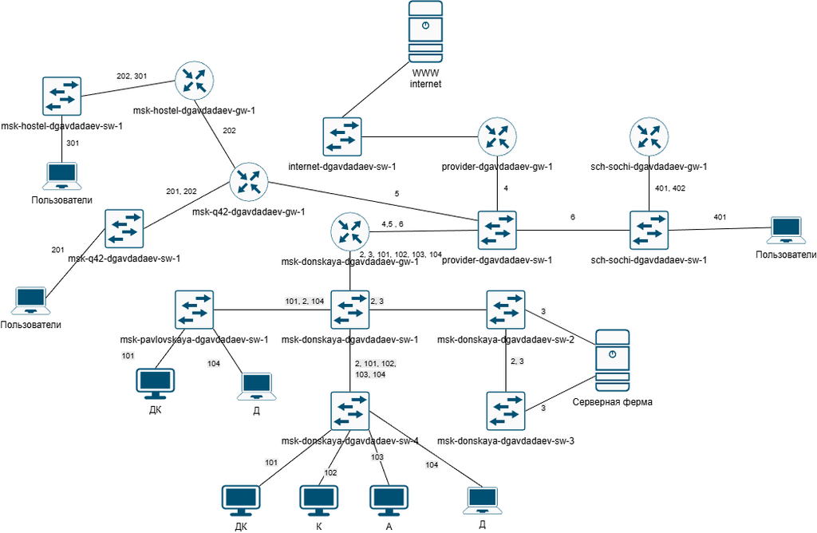

Схема сети уровня L2

## Схема сети уровня L3

На схеме L3 представлена логическая структура сети с указанием IP-подсетей и маршрутизируемых сегментов.

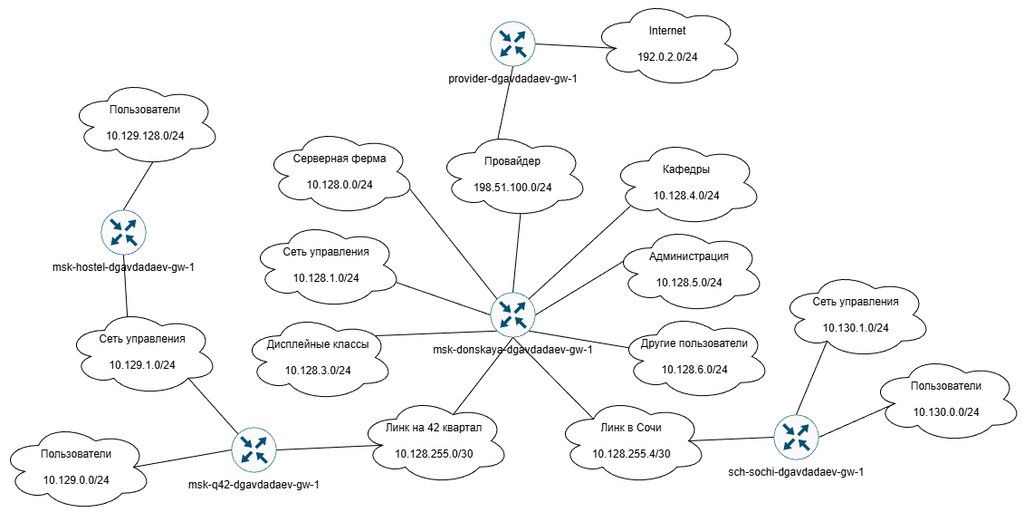

Схема сети уровня L3

# Выводы

## Итог лабораторной работы

В ходе выполнения лабораторной работы:

- дополнена схема проекта в Cisco Packet Tracer
- добавлена подсеть основной территории организации в 42-м квартале Москвы
- добавлена подсеть филиала организации в г. Сочи
- выполнена первоначальная настройка добавленного оборудования
- настроены параметры локального и удалённого доступа
- включён защищённый доступ по SSH
- в отчет включены обновленные схемы L1, L2 и L3